# EnergyConsumptionPred

## TASK 1

1. Build a basic predictive model to forecast the next 24 hours of electricity demand for the site. Evaluate your model and compare it to a naive benchmark. Briefly comment why, or why not, you think your model outperformed the naive benchmark.

```python
import pandas as pd
import numpy as np
import matplotlib.pyplot as plt
from prophet import Prophet
from sklearn.metrics import mean_absolute_error, mean_squared_error
```

```python
df = pd.read_csv('assessment_demand_data.csv')
```

```python
df.head()
```

|  | period_starting | mean_demand_kw |
| --- | --- | --- |
| 0 | 2023-04-01 00:00:00 | 216.0 |
| 1 | 2023-04-01 00:30:00 | 225.0 |
| 2 | 2023-04-01 01:00:00 | 221.0 |
| 3 | 2023-04-01 01:30:00 | 207.0 |
| 4 | 2023-04-01 02:00:00 | 216.0 |

```python
df.dtypes
```

```
period_starting     object
mean_demand_kw     float64
dtype: object
```

```python
df.columns = ['ds', 'y']
```

```python
df.head()
```

|  | ds | y |
| --- | --- | --- |
| 0 | 2023-04-01 00:00:00 | 216.0 |
| 1 | 2023-04-01 00:30:00 | 225.0 |
| 2 | 2023-04-01 01:00:00 | 221.0 |
| 3 | 2023-04-01 01:30:00 | 207.0 |
| 4 | 2023-04-01 02:00:00 | 216.0 |

```python
df['ds'] = pd.to_datetime(df['ds'])
```

```python
df.tail()
```

|  | ds | y |
| --- | --- | --- |
| 8779 | 2023-09-30 21:30:00 | 221.0 |
| 8780 | 2023-09-30 22:00:00 | 202.0 |
| 8781 | 2023-09-30 22:30:00 | 205.0 |
| 8782 | 2023-09-30 23:00:00 | 198.0 |
| 8783 | 2023-09-30 23:30:00 | 200.0 |

```python
df.dtypes
```

```
ds    datetime64[ns]
y            float64
dtype: object
```

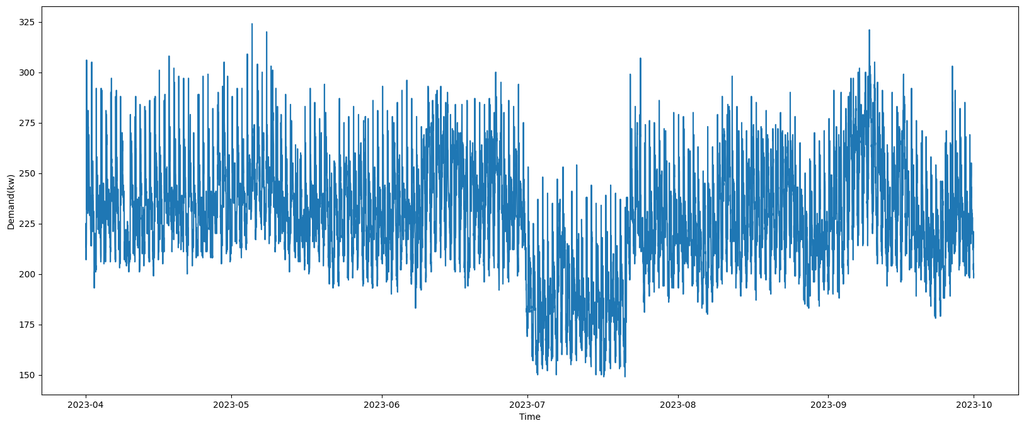

```python
plt.figure(figsize=(20,8))
plt.plot(df['ds'], df['y'])
plt.xlabel('Time')
plt.ylabel('Demand(kw)')
plt.show()
```

```python
model = Prophet()
```

```python
model.fit(df)
```

```
17:23:16 - cmdstanpy - INFO - Chain [1] start processing
17:23:19 - cmdstanpy - INFO - Chain [1] done processing
```

```
<prophet.forecaster.Prophet at 0x1aff34244d0>
```

```python
model.component_modes
```

```
{'additive': ['weekly',
  'daily',
  'additive_terms',
  'extra_regressors_additive',
  'holidays'],
 'multiplicative': ['multiplicative_terms', 'extra_regressors_multiplicative']}
```

```python
#making future next 24 hours in the dataframe with 48 periods
future = model.make_future_dataframe(periods=48, freq='30min')
```

```python
future.tail()
```

|  | ds |
| --- | --- |
| 8827 | 2023-10-01 21:30:00 |
| 8828 | 2023-10-01 22:00:00 |
| 8829 | 2023-10-01 22:30:00 |
| 8830 | 2023-10-01 23:00:00 |
| 8831 | 2023-10-01 23:30:00 |

```python
prediction = model.predict(future)
```

```python
prediction.tail()
```

|  | ds | trend | yhat_lower | yhat_upper | trend_lower | trend_upper | additive_terms | additive_terms_lower | additive_terms_upper | daily | daily_lower | daily_upper | weekly | weekly_lower | weekly_upper | multiplicative_terms | multiplicative_terms_lower | multiplicative_terms_upper | yhat |
| --- | --- | --- | --- | --- | --- | --- | --- | --- | --- | --- | --- | --- | --- | --- | --- | --- | --- | --- | --- |
| 8827 | 2023-10-01 21:30:00 | 228.067502 | 191.650628 | 236.921859 | 228.067502 | 228.067502 | -14.600682 | -14.600682 | -14.600682 | -9.317150 | -9.317150 | -9.317150 | -5.283532 | -5.283532 | -5.283532 | 0.0 | 0.0 | 0.0 | 213.466820 |
| 8828 | 2023-10-01 22:00:00 | 228.064504 | 188.901627 | 234.313585 | 228.064504 | 228.064504 | -17.025567 | -17.025567 | -17.025567 | -11.802527 | -11.802527 | -11.802527 | -5.223040 | -5.223040 | -5.223040 | 0.0 | 0.0 | 0.0 | 211.038937 |
| 8829 | 2023-10-01 22:30:00 | 228.061507 | 183.876869 | 231.241592 | 228.061507 | 228.061507 | -19.734834 | -19.734834 | -19.734834 | -14.581305 | -14.581305 | -14.581305 | -5.153529 | -5.153529 | -5.153529 | 0.0 | 0.0 | 0.0 | 208.326672 |
| 8830 | 2023-10-01 23:00:00 | 228.058509 | 182.098848 | 227.061621 | 228.058509 | 228.058509 | -22.573443 | -22.573443 | -22.573443 | -17.498152 | -17.498152 | -17.498152 | -5.075290 | -5.075290 | -5.075290 | 0.0 | 0.0 | 0.0 | 205.485066 |
| 8831 | 2023-10-01 23:30:00 | 228.055512 | 179.253551 | 225.244727 | 228.055512 | 228.055512 | -25.308877 | -25.308877 | -25.308877 | -20.320241 | -20.320241 | -20.320241 | -4.988636 | -4.988636 | -4.988636 | 0.0 | 0.0 | 0.0 | 202.746635 |

```python
df.tail()
```

|  | ds | y |
| --- | --- | --- |
| 8779 | 2023-09-30 21:30:00 | 221.0 |
| 8780 | 2023-09-30 22:00:00 | 202.0 |
| 8781 | 2023-09-30 22:30:00 | 205.0 |
| 8782 | 2023-09-30 23:00:00 | 198.0 |
| 8783 | 2023-09-30 23:30:00 | 200.0 |

```python
future.tail()
```

|  | ds |
| --- | --- |
| 8827 | 2023-10-01 21:30:00 |
| 8828 | 2023-10-01 22:00:00 |
| 8829 | 2023-10-01 22:30:00 |
| 8830 | 2023-10-01 23:00:00 |
| 8831 | 2023-10-01 23:30:00 |

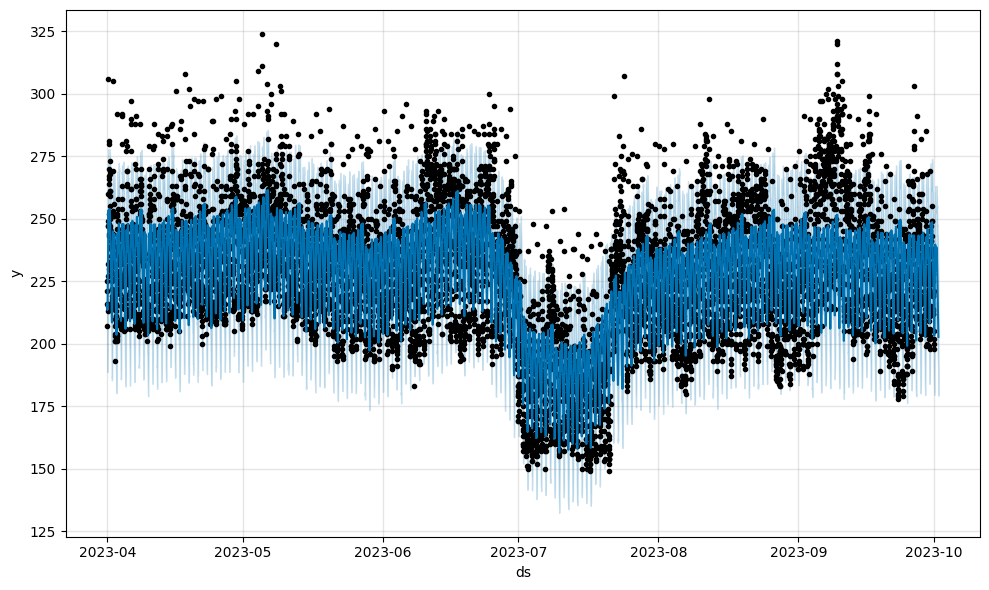

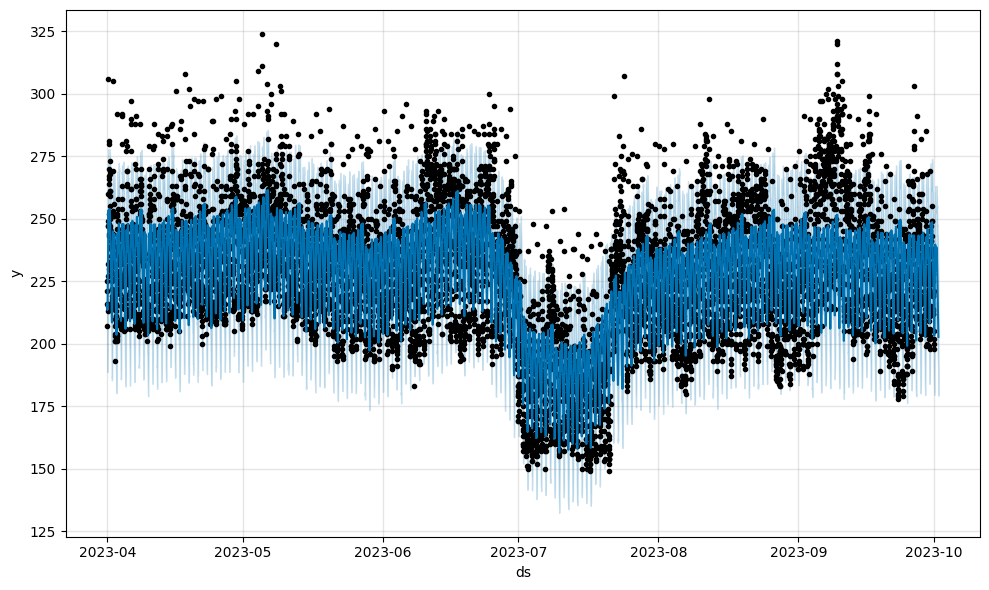

```python
model.plot(prediction)
```

```python
future_forecast = prediction[prediction['ds'] > df['ds'].max()]
```

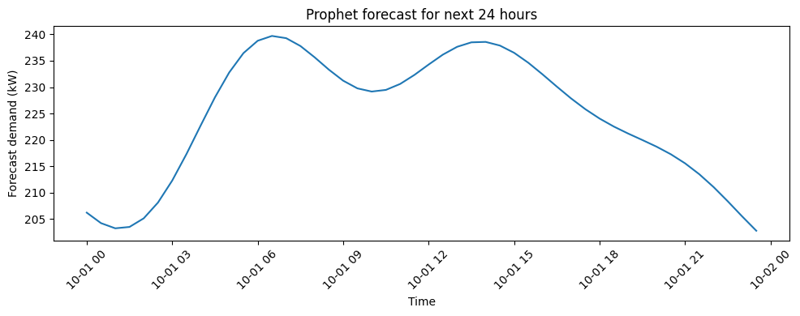

```python
plt.figure(figsize=(10,4))
plt.plot(future_forecast['ds'], future_forecast['yhat'])
plt.xlabel('Time')
plt.ylabel('Forecast demand (kW)')
plt.title('Prophet forecast for next 24 hours')
plt.xticks(rotation=45)
plt.tight_layout()
plt.show()
```

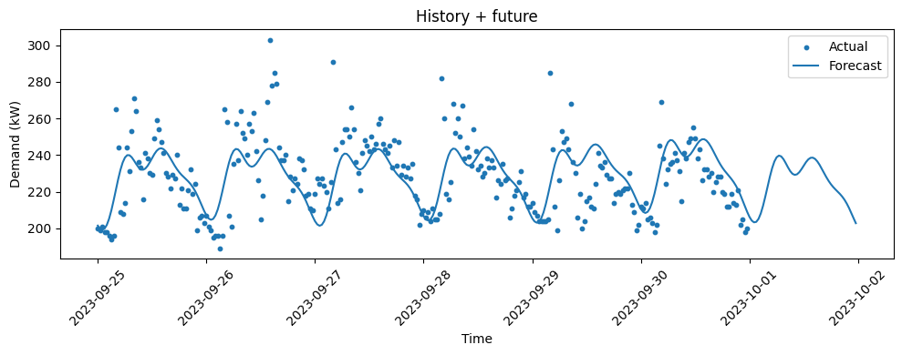

```python
#plotting for a zoomed view where history and future hours available
start = pd.to_datetime('2023-09-25')
end   = prediction['ds'].max()

hist_zoom = df[(df['ds'] >= start) & (df['ds'] <= end)]

# forecast (history + future) in same window
fcst_zoom = prediction[(prediction['ds'] >= start) & (prediction['ds'] <= end)]

plt.figure(figsize=(10,4))
# original data points
plt.scatter(hist_zoom['ds'], hist_zoom['y'], s=10, label='Actual')
# forecast line (history + future)
plt.plot(fcst_zoom['ds'], fcst_zoom['yhat'], label='Forecast')
plt.xlabel('Time')
plt.ylabel('Demand (kW)')
plt.title('History + future')
plt.legend()
plt.xticks(rotation=45)
plt.tight_layout()
plt.show()
```

```python
df['y_naive'] = df['y'].shift(48) #24 hours
```

```python
test_day = '2023-09-30'
mask_test = df['ds'].dt.date == pd.to_datetime(test_day).date()
df_test = df[mask_test]  # y = actual, y_naive = same time yesterday
```

```python
#checking naive benchmark
y_true = df_test['y']
y_naive = df_test['y_naive']

mae_naive = mean_absolute_error(y_true, y_naive)
rmse_naive = np.sqrt(mean_squared_error(y_true, y_naive))

print(f'Naive MAE:', mae_naive)
print(f'Naive RMSE:', rmse_naive)
```

```
Naive MAE: 13.229166666666666
Naive RMSE: 18.694361895145462
```

```python
df_test_sorted = df_test.sort_values('ds')
fcst_small = prediction[['ds', 'yhat']]

df_eval = df_test_sorted[['ds', 'y']].merge(fcst_small, on='ds', how='inner').sort_values('ds')
```

```python
#checking my prophet benchmark
y_true = df_eval['y'].values
y_prophet = df_eval['yhat'].values

mae_prophet = mean_absolute_error(y_true, y_prophet)
rmse_prophet = np.sqrt(mean_squared_error(y_true, y_prophet))

print(f'Prophet MAE:', mae_prophet)
print(f'Prophet RMSE:', rmse_prophet)
```

```
Prophet MAE: 11.754454927473242
Prophet RMSE: 13.722591841700964
```

### Model evaluation and discussion

From the exploratory plots, the site demand shows a clear daily pattern(low at night, high during day/evening) and a slower level shifts(for example dip around June-July). I wanted a model that captures the overall trend.

- A smooth trend over time,
- Strong daily and weekly seasonality,
- Without heavy tuning or complex deep learning

Prophet is designed exactly for this type of problem. Prophet models the time series as a combination of trend + seasonal components and can quickly fit daily/weekly patterns on half-hourly data(30 min = 1 period). It is also simple to implement and interpret in the limited time available for the assessment, so I chose it as my forecasting model.

### Naive Benchmark

As a benchmark I used a daily seasonal naive model, where the forecast for each half-hour is simply the demand at the same time on the previous day(48 periods before). For electricity demand this is a strong baseline, because load profiles are often very similar from one day to the next.

### Why prophet outperformed the naive model

The naive forcast exactly copies yesterday's profile, so it works well when today and yesterday look almost similar or identical. However it can't adjust for:

- Gradual level changes across days,
- Small shifts in the timing/shape of daily curve

Prophet fits a smooth daily and weekly seasonal pattern and an overall trend using all the historical data, so it can slightly adjust the expected load shape rather than blindly copying the previous day.

Overall, the result suggest that the naive model is a strong baseline due to the repetitive daily pattern however Prophet adds value by capturing the underlying seasonal structure and medium-term changes in demand.

## TASK 2

Assume the site has a battery with a maximum export power of 220 kW and an energy capacity of 440 kWh. Assume the battery is perfectly efficient and can be charged to completely full and discharged to completely empty without issue. It starts the day at 2023-10-01 00:00:00 with a state of energy of 220 kWh, i.e. half full. Assume the battery can charge from the grid, and discharge into the site to fully or partially meet demand, but cannot export into the grid to receive export payments.

2. Produce a plan for battery charging and discharging to minimize cost-to-supply the property over the next 24 hours. Compare the optimized cost-to-supply to the cost the customer would incur without a battery. Visualize the projected state of energy of the battery over the next 24 hours. The algorithm that produces this plan may be as simple or as complex as required.

```python
tariff = pd.read_csv('assessment_tariff_data.csv')
```

```python
tariff.head()
```

|  | period_starting | price_pence_per_kwh |
| --- | --- | --- |
| 0 | 2023-10-01 00:00:00 | 21 |
| 1 | 2023-10-01 00:30:00 | 21 |
| 2 | 2023-10-01 01:00:00 | 21 |
| 3 | 2023-10-01 01:30:00 | 21 |
| 4 | 2023-10-01 02:00:00 | 21 |

```python
tariff['period_starting'] = pd.to_datetime(tariff['period_starting'])
```

```python
tariff.columns = ['ds', 'price']
```

```python
prediction = prediction[prediction['ds'] > df['ds'].max()][['ds','yhat']].copy()
prediction = prediction.sort_values('ds')
```

```python
plan = prediction.merge(tariff[['ds', 'price']], on = 'ds')
```

```python
plan = plan.rename(columns = {'yhat' : 'demand_kw'})
```

```python
plan.head()
```

|  | ds | demand_kw | price |
| --- | --- | --- | --- |
| 0 | 2023-10-01 00:00:00 | 206.181647 | 21 |
| 1 | 2023-10-01 00:30:00 | 204.191788 | 21 |
| 2 | 2023-10-01 01:00:00 | 203.207706 | 21 |
| 3 | 2023-10-01 01:30:00 | 203.468105 | 21 |
| 4 | 2023-10-01 02:00:00 | 205.102165 | 21 |

#### Without Battery

```python
dt_hours = 0.5
plan['demand_kw'] = plan['demand_kw'] * dt_hours
```

```python
plan.head()
```

|  | ds | demand_kw | price |
| --- | --- | --- | --- |
| 0 | 2023-10-01 00:00:00 | 103.090824 | 21 |
| 1 | 2023-10-01 00:30:00 | 102.095894 | 21 |
| 2 | 2023-10-01 01:00:00 | 101.603853 | 21 |
| 3 | 2023-10-01 01:30:00 | 101.734052 | 21 |
| 4 | 2023-10-01 02:00:00 | 102.551082 | 21 |

```python
plan['cost_without_batt'] = plan['demand_kw'] * plan['price']
```

```python
total_cost_without_batt = plan['cost_without_batt'].sum()
```

```python
print(f"Cost without Battery:", total_cost_without_batt)
```

```
Cost without Battery: 141849.01380340237
```

#### With Battery

```python
max_kw = 220
max_kwh = 440
dt_hours = 0.5
max_enery_given_per_period = max_kw * dt_hours
```

```python
state_kwh = 220 #start with half full
```

```python
state_kwh_list = []
charge = []
discharge = []
import_grid = []
cost_with_batt = []
```

```python
low_threshold = plan['price'].quantile(0.3)
upper_threshold = plan['price'].quantile(0.7)
```

```python
state_kwh_list = [state_kwh]
for i in range(len(plan)):
    demand_kwh = plan.iloc[i]['demand_kw']
    price = plan.iloc[i]['price']

    charge_kwh = 0.0
    discharge_kwh = 0.0

    if price <= low_threshold and state_kwh < max_kwh:
        room_kwh = max_kwh - state_kwh
        charge_kwh = min(max_enery_given_per_period, room_kwh)
    elif price >= upper_threshold and state_kwh > 0:
        max_discharge_possible = min(max_enery_given_per_period, state_kwh, demand_kwh)
        discharge_kwh = max_discharge_possible

    state_kwh = state_kwh + charge_kwh - discharge_kwh
    state_kwh = max(0.0, min(max_kwh, state_kwh))


    grid_import_kwh = demand_kwh + charge_kwh - discharge_kwh
    step_cost = grid_import_kwh * price

    state_kwh_list.append(state_kwh)
    charge.append(charge_kwh)
    discharge.append(discharge_kwh)
    import_grid.append(grid_import_kwh)
    cost_with_batt.append(step_cost)
```

```python
print(len(plan), len(state_kwh_list))
plan['state_kwh'] = state_kwh_list[1:]
plan['charge_kwh'] = charge
plan['discharge_kwh'] = discharge
plan['grid_import_kwh'] = import_grid
plan['cost_with_batt'] = cost_with_batt

total_cost_with_batt = plan['cost_with_batt'].sum()
print(f"Cost with Battery: ",total_cost_with_batt)
```

```
48 49
Cost with Battery:  134589.0138034024
```

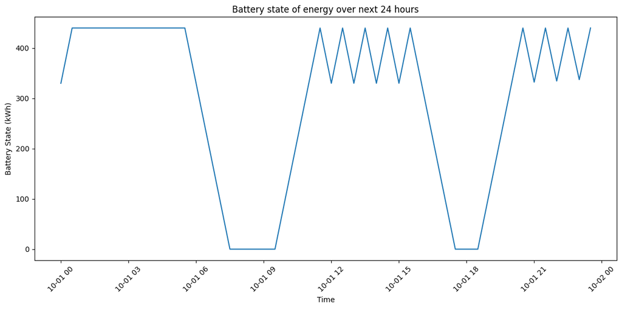

```python
plt.figure(figsize=(12,6))
plt.plot(plan["ds"], plan["state_kwh"])
plt.xlabel("Time")
plt.ylabel("Battery State (kWh)")
plt.title("Battery state of energy over next 24 hours")
plt.xticks(rotation=45)
plt.tight_layout()
plt.show()
```